# p8105_hw1_yq2279

Qi Yuchen

2019-09-15

# Problem 1

```r
library(tidyverse)
```

First, we Create a dataframe containing variables of four different types, and try to take the mean of each variable in the dataframe.

```r
# create a dataframe
df = tibble(
  vec_numeric = rnorm(8),
  vec_logical = vec_numeric > 0,
  vec_char = c("My", "name", "is", "Chloe", ".", "Good", "day", "."),
  vec_factor = factor(c("male", "male", "female", "female", "male", "male", "male", "female"))
)

# take the mean of each variable
mean_numeric = mean(pull(df, vec_numeric))
mean_logical = mean(pull(df, vec_logical))
mean_char = mean(pull(df, vec_char))
mean_factor = mean(pull(df, vec_factor))
```

From the above we can see when taking the mean, the numerical vector and logical vector work, the character vector and the factor vector don’t.

Next, we convert the logical, character, and factor variables to numeric.

```r
logical_to_num = as.numeric(pull(df, vec_logical))
char_to_num = as.numeric(pull(df, vec_char))
factor_to_num = as.numeric(pull(df, vec_factor))
```

The logical and factor variables can be converted, and the character variable cannot.

Now, we do the last part of problem 1.

Convert the logical vector to numeric, and multiply the random sample by the result.

```r
# convert the logical vector to numeric
logical_to_num = as.numeric(pull(df, vec_logical))

# multiply the random sample by the result
logical_to_num_multi_s = logical_to_num * pull(df, vec_numeric)
```

Convert the logical vector to a factor, and multiply the random sample by the result.

```r
# convert the logical vector to a factor
logical_to_fac = as.factor(pull(df, vec_logical))

# multiply the random sample by the result
logical_to_fac_multi_s = logical_to_fac * pull(df, vec_numeric)
```

Convert the logical vector to a factor and then convert the result to numeric, and multiply the random sample by the result.

```r
# convert the logical vector to a factor
logical_to_fac = as.factor(pull(df, vec_logical))

#  convert the result to numeric
logical_to_fac_to_num = as.numeric(logical_to_fac)

# multiply the random sample by the result
logical_to_fac_to_num_multi_s = logical_to_fac_to_num * pull(df, vec_numeric)
```

# Problem 2

```r
rm(list = ls())
library(tidyverse)
```

First we Create a data frame.

```r
df = tibble(
  x = rnorm(500),
  y = rnorm(500),
  vec_logical = x + y > 1,
  vec_num = as.numeric(vec_logical),
  vec_fac = as.factor(vec_logical)
)
```

- The size of the dataset is nrow = 500, ncol = 5.
- the mean, median, and standard deviation of x is 0.0204645, 0.108002, and 1.0187716.

Then make a scatterplot of y vs x; color points using the logical variable.

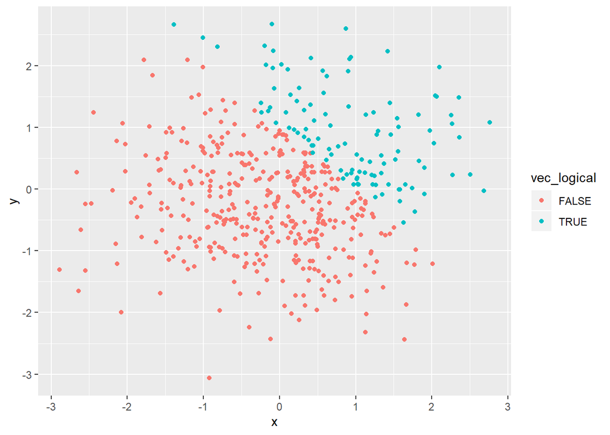

```r
ggplot(df, aes(x = x, y = y, color = vec_logical)) + geom_point()
```

```r
ggsave(file = "plot_logical_variable.png")
```

Color points using the numeric variable.

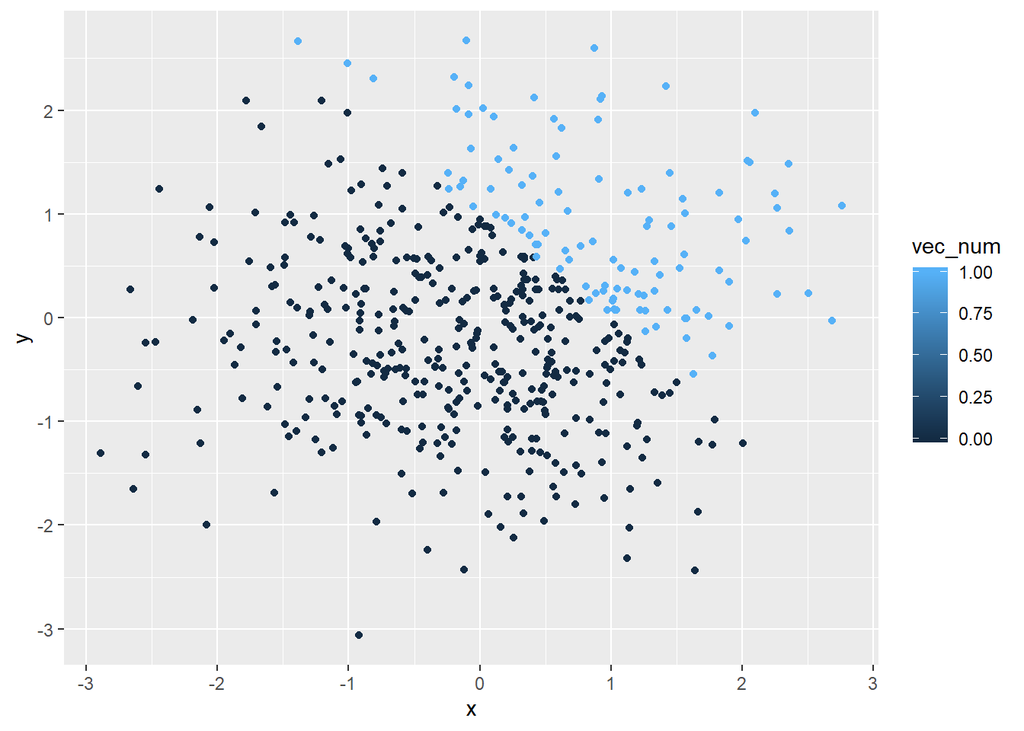

```r
ggplot(df, aes(x = x, y = y, color = vec_num)) + geom_point()
```

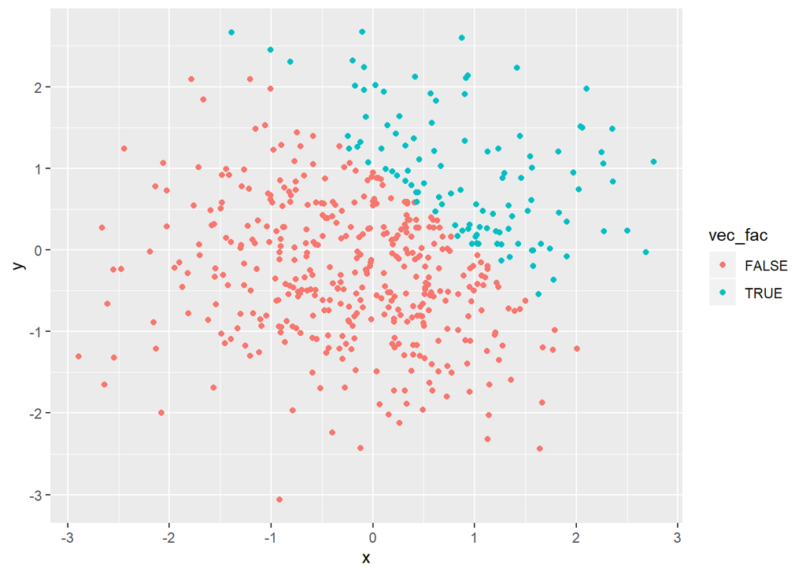

```r
ggplot(df, aes(x = x, y = y, color = vec_fac)) + geom_point()
```